# 03 – Are the mutants what we think they are?

Bio253 HS2026 · validating stk1::Tn and stp1::Tn

**Goal:** before you interpret any “stk vs anc” or “stp vs anc” difference, check that the mutant strains really lack the protein they are supposed to lack – and *only* that one. This is routine in every good proteomics project.

The two mutants come from the Nebraska Transposon Mutant Library (NTML): a transposon (Tn) inserted into *stk1* (kinase, also called *pknB*) or *stp1* (phosphatase). In the genome, *stp1* lies directly upstream of *stk1*.

```r
source("../R/setup.R")
abundances <- read_abundances("total")
dea <- read_dea("total")
```

## 1. Find Stk1 and Stp1

```r
KEY_PROTEINS |> filter(short_name %in% c("Stk1", "Stp1"))
```

| short_name | locus_tag | protein_id | role |
| --- | --- | --- | --- |
| Stp1 | B7H15_06350 | ARG45702.1 | Ser/Thr phosphatase (mutated in ‘stp’) |
| Stk1 | B7H15_06355 | ARG45703.1 | Ser/Thr kinase PknB (mutated in ‘stk’), downstream of stp1 |

```r
find_protein(c("B7H15_06350", "B7H15_06355")) |>
  select(locus_tag, product, protein_id, location, staa8_uniprot)
```

| locus_tag | product | protein_id | location | staa8_uniprot |
| --- | --- | --- | --- | --- |
| B7H15_06350 | protein phosphatase | ARG45702.1 | 1232295..1233038 | Q2FZ65 |
| B7H15_06355 | serine/threonine protein kinase | ARG45703.1 | 1233035..1235029 | Q2FZ64 |

**Question:** look at the `location` column. Which gene comes first? Do they overlap?

## 2. Prediction

Write down **before** plotting:

| strain | Stp1 expected | Stk1 expected |
| --- | --- | --- |
| anc | present | present |
| stk | ? | ? |
| stp | ? | ? |

## 3. Per-sample abundances

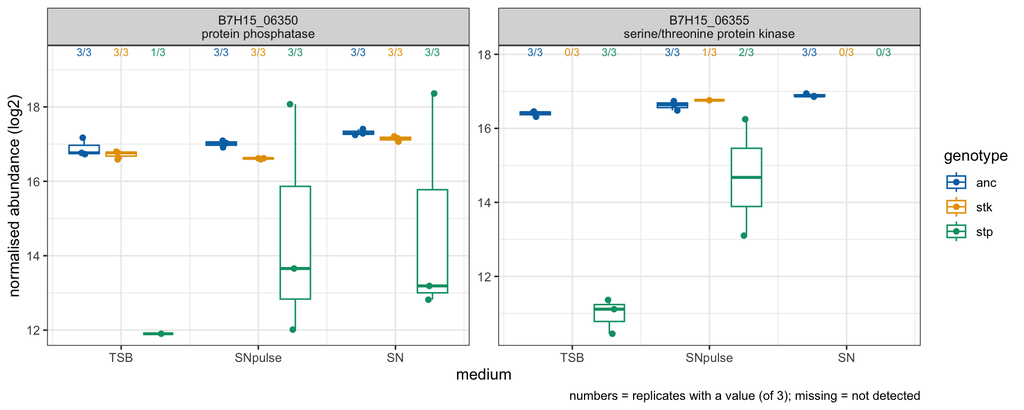

```r
plot_protein(c("B7H15_06350", "B7H15_06355"), abundances)
```

```r
abundances |>
  filter(locus_tag %in% c("B7H15_06350", "B7H15_06355")) |>
  mutate(protein = if_else(locus_tag == "B7H15_06350", "Stp1", "Stk1")) |>
  select(protein, sample, normalized_abundance) |>
  pivot_wider(names_from = protein, values_from = normalized_abundance) |>
  mutate(across(where(is.numeric), \(v) round(v, 1)))
```

| sample | Stp1 | Stk1 |
| --- | --- | --- |
| JE2anc_TSB_1 | 16.8 | 16.4 |
| JE2anc_TSB_2 | 17.2 | 16.5 |
| JE2anc_TSB_3 | 16.7 | 16.3 |
| JE2anc_SN_1 | 17.4 | 16.9 |
| JE2anc_SN_2 | 17.2 | 16.9 |
| JE2anc_SN_3 | 17.3 | 16.9 |
| JE2anc_pulseSN_1 | 17.0 | 16.5 |
| JE2anc_pulseSN_2 | 16.9 | 16.6 |
| JE2anc_pulseSN_3 | 17.1 | 16.7 |
| JE2stk_TSB_1 | 16.8 | NA |
| JE2stk_TSB_2 | 16.8 | NA |
| JE2stk_TSB_3 | 16.6 | NA |
| JE2stk_SN_1 | 17.2 | NA |
| JE2stk_SN_2 | 17.2 | NA |
| JE2stk_SN_3 | 17.1 | NA |
| JE2stk_pulseSN_1 | 16.6 | 16.8 |
| JE2stk_pulseSN_2 | 16.6 | NA |
| JE2stk_pulseSN_3 | 16.6 | NA |
| JE2stp_TSB_1 | NA | 11.4 |
| JE2stp_TSB_2 | 11.9 | 10.5 |
| JE2stp_TSB_3 | NA | 11.1 |
| JE2stp_SN_1 | 13.2 | NA |
| JE2stp_SN_2 | 18.4 | NA |
| JE2stp_SN_3 | 12.8 | NA |
| JE2stp_pulseSN_1 | 12.0 | 13.1 |
| JE2stp_pulseSN_2 | 13.7 | 16.2 |
| JE2stp_pulseSN_3 | 18.1 | NA |

**Questions**

1. Is Stk1 gone in `stk`? Is it gone in *every* `stk` sample? (Look closely at each replicate.)
2. What happens to **Stk1 in the `stp` strain**? Was that in your prediction?
3. Is Stp1 gone in `stp`? How consistent are the replicates? Are some values as high as in the wild type? What could explain that (think: sample mix-up, carry-over, revertants, mixed culture, peptide mis-assignment)?
4. Is Stp1 changed in `stk`?

## 4. The DEA view – and why it can mislead here

```r
dea |>
  filter(locus_tag %in% c("B7H15_06350", "B7H15_06355"),
         str_detect(contrast, "^(stk|stp)_vs_anc_at_")) |>
  mutate(protein = if_else(locus_tag == "B7H15_06350", "Stp1", "Stk1")) |>
  transmute(protein, contrast, diff = round(diff, 2), FDR = signif(FDR, 2), estimate_type) |>
  arrange(protein, contrast)
```

| protein | contrast | diff | FDR | estimate_type |
| --- | --- | --- | --- | --- |
| Stk1 | stk_vs_anc_at_SN | -2.83 | 5.3e-05 | lod_imputed |
| Stk1 | stk_vs_anc_at_SNpulse | -1.66 | 2.6e-03 | lod_imputed |
| Stk1 | stk_vs_anc_at_TSB | -2.34 | 2.4e-04 | lod_imputed |
| Stk1 | stp_vs_anc_at_SN | -2.83 | 6.7e-05 | lod_imputed |
| Stk1 | stp_vs_anc_at_SNpulse | -2.01 | 2.2e-04 | lod_imputed |
| Stk1 | stp_vs_anc_at_TSB | -2.34 | 4.7e-05 | lod_imputed |
| Stp1 | stk_vs_anc_at_SN | -0.17 | 8.3e-01 | observed |
| Stp1 | stk_vs_anc_at_SNpulse | -0.40 | 5.6e-01 | observed |
| Stp1 | stk_vs_anc_at_TSB | -0.17 | 8.4e-01 | observed |
| Stp1 | stp_vs_anc_at_SN | -1.63 | 1.7e-01 | observed |
| Stp1 | stp_vs_anc_at_SNpulse | -3.07 | 9.9e-03 | observed |
| Stp1 | stp_vs_anc_at_TSB | -4.98 | 2.3e-02 | observed |

**Question:** Several rows are `lod_imputed`. What does a log2FC of, say, −5 mean when one group was *never measured*? Why might the FDR of the “absent” protein be less impressive than you expect?

## 5. A polar effect? Look at the neighbours

Transposon insertions can disturb the expression of genes **downstream in the same operon** (polar effect). If *stp1::Tn* reduces Stk1, the neighbourhood should tell us more.

```r
neighbours <- sprintf("B7H15_%05d", seq(6335, 6370, by = 5))
read_annotation() |>
  filter(locus_tag %in% neighbours) |>
  select(locus_tag, product, location)
```

| locus_tag | product | location |
| --- | --- | --- |
| B7H15_06335 | methionyl-tRNA formyltransferase | 1228952..1229887 |
| B7H15_06340 | 16S rRNA (cytosine(967)-C(5))-methyltransferase | 1229884..1231191 |
| B7H15_06345 | 23S rRNA (adenine(2503)-C(2))-methyltransferase RlmN | 1231194..1232288 |
| B7H15_06350 | protein phosphatase | 1232295..1233038 |
| B7H15_06355 | serine/threonine protein kinase | 1233035..1235029 |
| B7H15_06360 | ribosome small subunit-dependent GTPase A | 1235257..1236132 |
| B7H15_06365 | ribulose-phosphate 3-epimerase | 1236133..1236777 |
| B7H15_06370 | thiamine pyrophosphokinase | 1236784..1237425 |

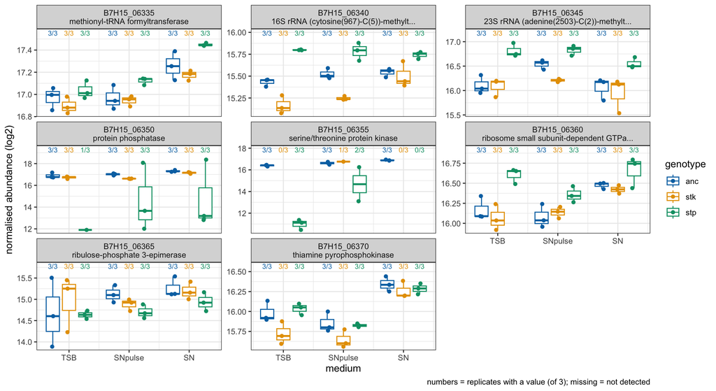

```r
plot_protein(neighbours, abundances)
```

**Questions**

- Which neighbours are unaffected in `stp`? Which are affected?
- Is “polar effect of the Tn insertion” the only explanation for low Stk1 in `stp`? (Alternatives: Stk1 protein unstable without Stp1, autoregulation, a second mutation in the strain …)
- What would you check in the lab? (e.g. PCR / sequencing of the insertion site, RT-qPCR of *stk1*, complementation strain)
- **Consequence:** if `stp` lacks *both* Stp1 and (mostly) Stk1, how should you interpret any `stp_vs_anc` result in the other notebooks?

## 6. Phospho sites on Stk1 and Stp1

Stk1 phosphorylates itself (autophosphorylation in its activation loop). If Stk1 is absent, its phospho-sites should be absent, too.

```r
sites <- read_sites("STYH")
stk_stp_sites <- sites |>
  filter(locus_tag %in% c("B7H15_06350", "B7H15_06355"))

stk_stp_sites |>
  group_by(locus_tag, site_id, residue, position, best_loc_prob, group) |>
  summarise(n = sum(!is.na(intensity)), .groups = "drop") |>
  pivot_wider(names_from = group, values_from = n, values_fill = 0) |>
  mutate(site = paste0(residue, position)) |>
  select(locus_tag, site, best_loc_prob, any_of(GROUPS)) |>
  arrange(locus_tag, as.integer(str_extract(site, "[0-9]+")))
```

| locus_tag | site | best_loc_prob | anc_TSB | anc_SNpulse | anc_SN | stk_TSB | stk_SNpulse | stk_SN | stp_TSB | stp_SNpulse | stp_SN |
| --- | --- | --- | --- | --- | --- | --- | --- | --- | --- | --- | --- |
| B7H15_06355 | S159 | 0.6208 | 3 | 2 | 2 | 0 | 0 | 0 | 1 | 0 | 0 |
| B7H15_06355 | T161 | 0.9215 | 2 | 3 | 3 | 0 | 0 | 0 | 0 | 0 | 0 |
| B7H15_06355 | S162 | 0.8911 | 3 | 3 | 3 | 0 | 0 | 0 | 0 | 0 | 0 |
| B7H15_06355 | T164 | 0.9370 | 3 | 3 | 3 | 0 | 0 | 0 | 3 | 1 | 2 |
| B7H15_06355 | T166 | 0.9362 | 3 | 3 | 3 | 0 | 0 | 0 | 3 | 1 | 1 |
| B7H15_06355 | H168 | 0.9028 | 3 | 3 | 3 | 0 | 0 | 0 | 1 | 2 | 2 |
| B7H15_06355 | T172 | 0.8654 | 3 | 3 | 2 | 0 | 0 | 0 | 0 | 2 | 1 |
| B7H15_06355 | Y175 | 0.5931 | 0 | 0 | 1 | 0 | 0 | 0 | 0 | 0 | 1 |
| B7H15_06355 | T231 | 0.8818 | 2 | 0 | 1 | 0 | 2 | 1 | 2 | 1 | 1 |
| B7H15_06355 | S240 | 0.8833 | 2 | 0 | 1 | 0 | 2 | 1 | 2 | 1 | 0 |
| B7H15_06355 | S242 | 0.8833 | 2 | 0 | 1 | 0 | 2 | 1 | 2 | 1 | 0 |
| B7H15_06355 | T288 | 1.0000 | 3 | 1 | 3 | 0 | 0 | 0 | 0 | 0 | 0 |
| B7H15_06355 | T314 | 0.9096 | 1 | 0 | 3 | 0 | 0 | 0 | 0 | 0 | 0 |
| B7H15_06355 | T315 | 0.8866 | 0 | 0 | 1 | 0 | 0 | 0 | 0 | 0 | 0 |

Numbers = in how many of the 3 replicates the site was detected.

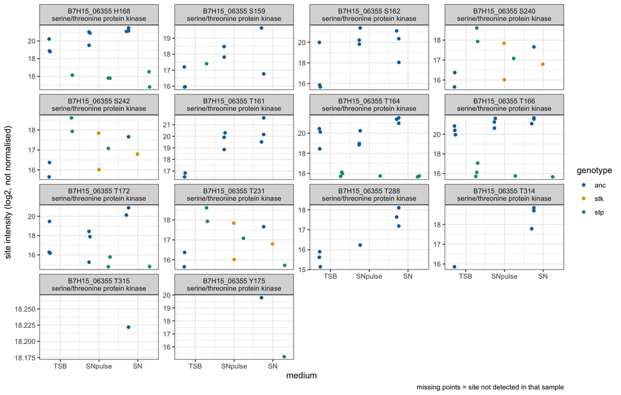

```r
plot_sites(unique(stk_stp_sites$site_id), sites)
```

**Questions**

- Which Stk1 residues are phosphorylated in the wild type? Where are they in the protein (look up the kinase domain / activation loop of PknB, UniProt Q2FZ64 is the NCTC8325 ortholog)?
- Are any Stk1 phospho-sites detected in the `stk` strain? If yes – where in the protein are they, and what could that say about **where** the transposon sits (a truncated protein?) or about the sample?
- Are there phospho-sites on Stp1 at all?
- One site is on a histidine. Keep it in mind for notebook 05.

## 7. Summary for your lab notebook

Write 3–5 sentences: which strain is a clean mutant, which is not, and what this means for the hypotheses you want to test.